# MIS40970 - Data Mining for Business Analytics

# 11 Calculate the mean price of orange juice sold each week, and create aline plot of this timeseries.

## 11.1 Method 1: using tapply()

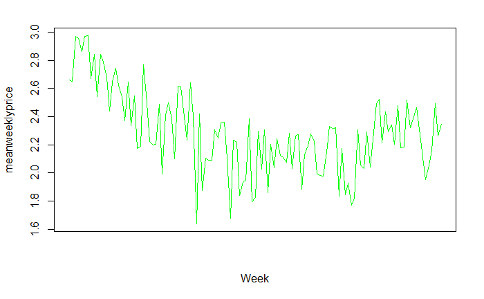

```r
xnames <- tapply(oj$price,oj$week,FUN=mean,na.rm=TRUE)
plot(tapply(oj$price,oj$week,FUN=mean,na.rm=TRUE),xaxt="n",pch=16,type="l",
     col="green",xlab = "Week",ylab="meanweeklyprice")
```

## 11.2 Method 2: using aggreagate()

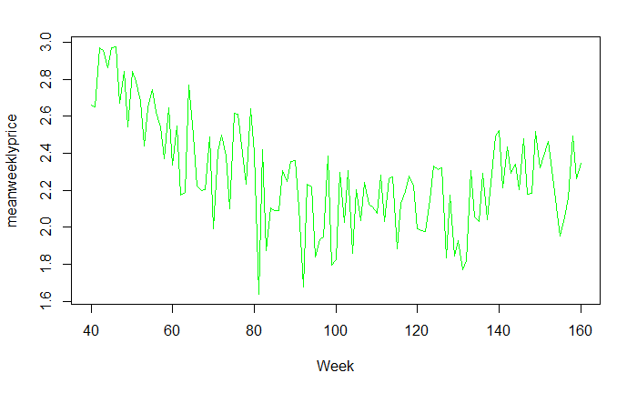

```r
meanweeklyprice <- aggregate(oj[ ,6], list(oj$week), mean)
plot(meanweeklyprice$Group.1,meanweeklyprice$x,type="l",col="green",
     xlab = "Week",ylab="meanweeklyprice")
```

# 12 Extract the mean weekly price of orange juice sold each week according to each brand.

## 12.1 Method 1: using aggregate()

```r
mean_weekly_brand_price <- aggregate(oj[ ,6], list(Brand=oj$brand,Week=oj$week), mean)
#mean_weekly_brand_price  #Uncomment this to view full data frame
head(mean_weekly_brand_price)
```

|  | Brand | Week | x |
| --- | --- | --- | --- |
| 1 | dominicks | 40 | 1.590000 |
| 2 | minute.maid | 40 | 2.890000 |
| 3 | tropicana | 40 | 3.509315 |
| 4 | dominicks | 41 | 2.447015 |
| 5 | minute.maid | 41 | 1.990000 |
| 6 | tropicana | 41 | 3.514627 |

## 12.2 Method :2 using tapply()

```r
weekly_brand_price<-tapply(oj$price,list(Week=oj$week,oj$brand),FUN=mean,na.rm=TRUE)
#weekly_brand_price  #Uncomment this to view full data frame
head(weekly_brand_price)
```

```
Week dominicks minute.maid tropicana
  40  1.590000    2.890000  3.509315
  41  2.447015    1.990000  3.514627
  42  2.461940    2.911343  3.536567
  43  2.452597    2.892597  3.517792
  44  2.463506    2.590000  3.534156
  45  2.467838    2.908649  3.541486
```

# 13 Create a plot which compares the mean weekly price of orange juice for all brands versus each individual brand.

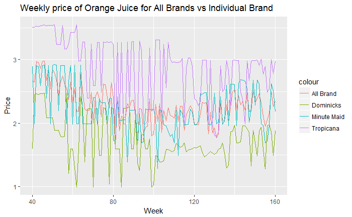

```r
weekly_brand_price<-tapply(oj$price,list(Week=oj$week,oj$brand),FUN=mean,na.rm=TRUE)
allbrand <- tapply(oj$price,list(Week=oj$week),FUN=mean,na.rm=TRUE)
df <- cbind(allbrand,weekly_brand_price)
write.table(df, file = 'q13.csv',sep = ",",row.names = T)
library(readr)
q13 <- read_csv("E:/Smurfit/Semester 2/DM/R/Data-Mining/q13.csv",col_names = FALSE, skip = 1)
ggplot(q13, aes(q13$X1),pch=21) +
  geom_line(aes(y = q13$X2, colour = "All Brand")) +
  geom_line(aes(y = q13$X3, colour = "Dominicks")) +
  geom_line(aes(y = q13$X4, colour = "Minute Maid")) +
  geom_line(aes(y = q13$X5, colour = "Tropicana")) + xlab("Week") +ylab("Price")+
  ggtitle("Weekly price of Orange Juice for All Brands vs Individual Brand")
```

# 14 When there is an advertising campaign for orange juice does it impact on the number of units sold?

Yes, more number of units sold when there is an advertising campaign

```r
adcap <- factor(oj$feat)
tapply(oj$logmove,adcap,FUN=mean,na.rm=TRUE)
```

```
        0         1
 8.862963 10.148049
```

# 15 Can you create a line plot of the mean weekly units sold without a promotion overlayed with the mean weekly units sold with a promotion? What is interesting about this plot

With a promotion more number of units sold as compared to campaign without a promotion

```r
unitsold<-tapply(oj$logmove,list(oj$week),FUN=mean,na.rm=TRUE)
head(unitsold)
```

```
      40       41       42       43       44       45
8.598766 8.942384 8.298204 8.429358 8.741467 8.140365
```

[figure not shown]

```r
sold <- tapply(oj$logmove,list(Week=oj$week,oj$feat),FUN=mean,na.rm=TRUE)
df <- cbind(sold)
write.table(df, file = 'q15.csv',sep = ",",row.names = T)
library(readr)
q15 <- read_csv("E:/Smurfit/Semester 2/DM/R/Data-Mining/q15.csv",col_names = FALSE, skip = 1)
ggplot(q15, aes(q13$X1,xlab="Week")) +
  geom_line(aes(y = q13$X2, colour = "With promotion")) +
  geom_line(aes(y = q13$X3, colour = "Without promotion"))+ xlab("Week") +ylab("Units Sold")+
  ggtitle("Mean weekly units sold with a promotion vs without promotion")
```

# 16 Descriptive Analytics

Consider the demographic and competitive variables1. Using descriptive analytics are there patterns you can observe that might suggest the potential for profiling individual stores or customers, which might then be used for marketing purposes?

## 16.1 Answer: Yes, there are patterns among demographics variables, which can be use for marketing of orange juice at given stores.

1. Data Cleaning: This help in identifying and removing duplicate records along with outlier, which might diverge business decision.
2. Descriptive Analytics: Using this one understand the behaviour, size, and range etc about data points.
3. Correlations: One can use highly correlated variables into account while forming a new marketing strategy. Such as, in given data, EDUC and HVAL150 are very much related to each other, this give us an insight that potential customer who are well educated also lives in an expensive house and vice verse. Similarly, HVAL150, INCOME and EDUC also correlated with each other.
4. Distribution: By plotting probability distribution of chart, one can figure out the probability of future business decision outcome.
5. Store Rating: Using statistical analysis, one can identify the best and worst store, also can rate each store depending on units sold by them. It is found that store 75 is poorest and store 62 is the wealthiest store among 83 stores.
6. Linear Models: By generating linear models of each variable, one can analysis the trend of data, which will help in forecasting future trend as well.

## 16.2 Overview

Actual data contains 28947 observations and 12 variables for demographic data.

```r
d1 <-(oj[c(1,7:17)])
dim(d1)
```

```
[1] 28947    12
```

On analysing the data, it is found that, there were only 83 unique records out of 28947 obsservations. Therefore, data should be cleaned before performing any further descriptive analytics.

```r
d2 <- unique(oj[c(1,7:17)])
dim(d2)
```

```
[1] 83 12
```

## 16.3 Descriptive Analytics Summary for demographic data

This analysis will help one to understand the data, how it is distrbuted and how many observations are there etc.

```r
oj_subset <- unique(oj[c(1,7:17)])
oj_stats <- do.call(data.frame,
           list(Mean = apply(oj_subset, 2, mean),
                Std_Dev = apply(oj_subset, 2, sd),
                Median = apply(oj_subset, 2, median),
                Min = apply(oj_subset, 2, min),
                Max = apply(oj_subset, 2, max),
                N = apply(oj_subset, 2, length)))
oj_stats
```

|  | Mean | Std_Dev | Median | Min | Max | N |
| --- | --- | --- | --- | --- | --- | --- |
| store | 80.9277108 | 35.93448752 | 86.00000000 | 2.00000000 | 137.0000000 | 83 |
| AGE60 | 0.1729724 | 0.06221013 | 0.17065481 | 0.05805397 | 0.3073979 | 83 |
| EDUC | 0.2257762 | 0.11114318 | 0.22939040 | 0.04955029 | 0.5283620 | 83 |
| ETHNIC | 0.1546351 | 0.18782770 | 0.07465643 | 0.02424657 | 0.9956908 | 83 |
| INCOME | 10.6176755 | 0.28344624 | 10.63532646 | 9.86708287 | 11.2361965 | 83 |
| HHLARGE | 0.1156640 | 0.03035444 | 0.11122120 | 0.01350636 | 0.2163543 | 83 |
| WORKWOM | 0.3591536 | 0.05280191 | 0.35563513 | 0.24446267 | 0.4723083 | 83 |
| HVAL150 | 0.3446528 | 0.24092599 | 0.34615385 | 0.00250941 | 0.9166995 | 83 |
| SSTRDIST | 5.0969450 | 3.48872894 | 4.65068687 | 0.13209682 | 17.8559508 | 83 |
| SSTRVOL | 1.2104260 | 0.53090387 | 1.11538461 | 0.40000000 | 2.5714286 | 83 |

[output cut: 2 more lines]

```r
stats_data =apply(as.matrix(oj_subset),2,quantile)
cat("Statisical Summary of Orange Juice Data",fill=TRUE)
```

```
Statisical Summary of Orange Juice Data
```

```r
print(stats_data)
```

```
     store      AGE60       EDUC     ETHNIC    INCOME    HHLARGE   WORKWOM    HVAL150   SSTRDIST
0%     2.0 0.05805397 0.04955029 0.02424657  9.867083 0.01350636 0.2444627 0.00250941  0.1320968
25%   53.5 0.12394915 0.14878867 0.04294112 10.468048 0.09804559 0.3129127 0.12895177  2.8399843
50%   86.0 0.17065481 0.22939040 0.07465643 10.635326 0.11122120 0.3556351 0.34615385  4.6506869
75%  110.5 0.21362903 0.28227241 0.17995974 10.795248 0.13345868 0.4021066 0.51703001  6.5742868
100% 137.0 0.30739786 0.52836201 0.99569076 11.236197 0.21635434 0.4723083 0.91669949 17.8559508
       SSTRVOL   CPDIST5    CPWVOL5
0%   0.4000000 0.7725297 0.09456175
25%  0.7272727 1.6346475 0.28043820
50%  1.1153846 1.9634124 0.38322679
75%  1.5504808 2.5336557 0.55988695
100% 2.5714286 4.1079018 1.14336661
```

## 16.4 Scatter Plot Matrices in R

### 16.4.1 Analysis of Correlation among demographics variables.

The closer correlation coeff(r) is to +1 or -1, the more closely the two variables are related. If r is close to 0, it means there is no relationship between the variables. Below are few sample correlated variables.

#### 16.4.1.1 1. Positive Correlations:

```
    1. EDUC ~ CPWVOL5
    2. WORKWOM ~ CPWVOL5
    3. EDUC ~ WORKWOM
    4. EDUC ~ HVAL150
    5. WORKWOM ~ HVAL150
    6. SSTRDIST ~ SSTRVOL
```

#### 16.4.1.2 1. Negative Correlations:

[output not shown]

EDUC and HVAL150 are highly correlated with each other, having r = 0.89 and p <= 0.01. This signifies that educated people having house which has value more than $150,000.

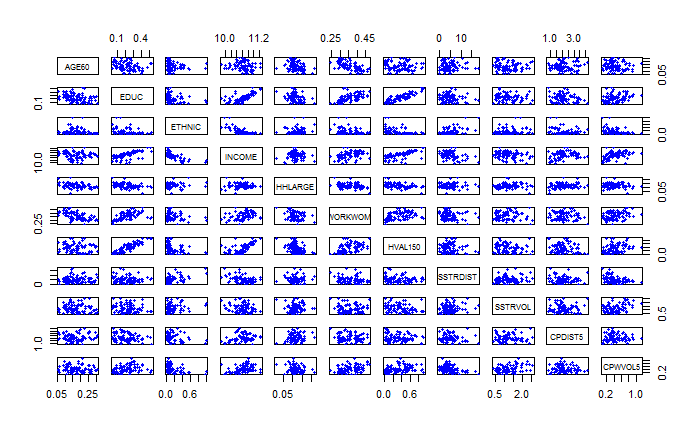

```r
#Scatter Plot to find correlation among demographics variables
pairs(oj_subset[,-1],col="blue",pch=20)
```

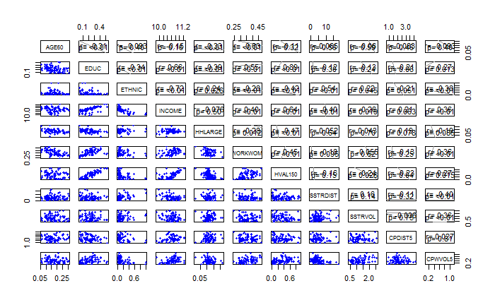

```r
#Reference: https://www.r-bloggers.com/scatter-plot-matrices-in-r/
#Scatter Plot with Correlation and P Value
panel.cor <- function(x, y, digits = 2, cex.cor=.8, ...)
{

  #Plotting Regression Line
  reg1 <- lm(x~y)
  abline(reg1,col = "gray60")

  usr <- par("usr"); on.exit(par(usr))
  par(usr = c(0, 1, 0, 1))
  # correlation coefficient
  r <- cor(x, y)
  txt <- format(c(r, 0.123456789), digits = digits)[1]
  txt <- paste("r= ", txt, sep = "")
  text(0.5, 0.6, txt)
  # p-value calculation
  p <- cor.test(x, y)$p.value
  txt2 <- format(c(p, 0.123456789), digits = digits)[1]
  txt2 <- paste("p= ", txt2, sep = "")
  if(p<0.01) txt2 <- paste("p= ", "<0.01", sep = "")
  text(0.5, 0.4, txt2)
}
pairs(oj_subset[,-1], upper.panel = panel.cor,col="blue",pch=20)
```

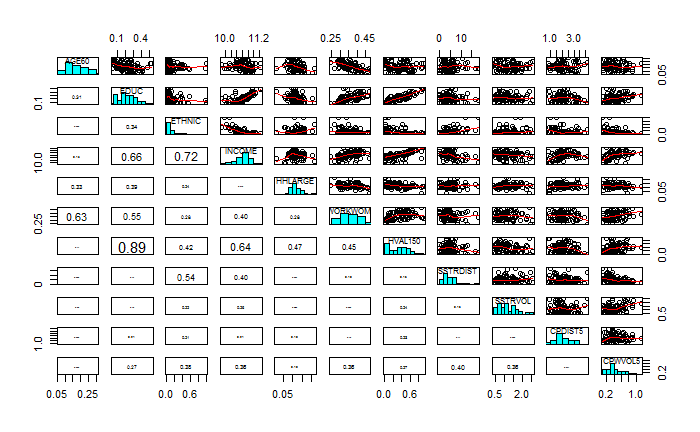

```r
library(s20x)
pairs20x(oj_subset[,-1])
```

## 16.5 Boxplot and Histogram for Data Analysis

With the help of Boxplot, one is able to identify any outliers in the data, thereafter histogram plots help in checking the distribution of data, i.e whether data is normally distributed or not.

1. EDUC, ETHNNIC, INCOME, HHLARGE, SSTRDIST, CPDIST5 and CPWVOL5 has outliers

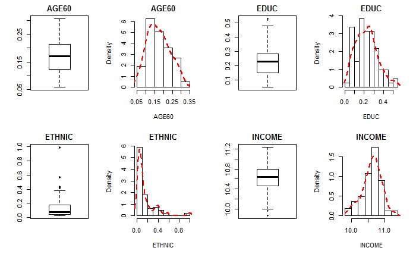

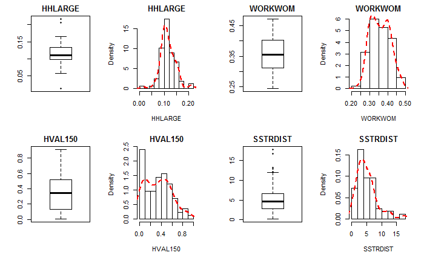

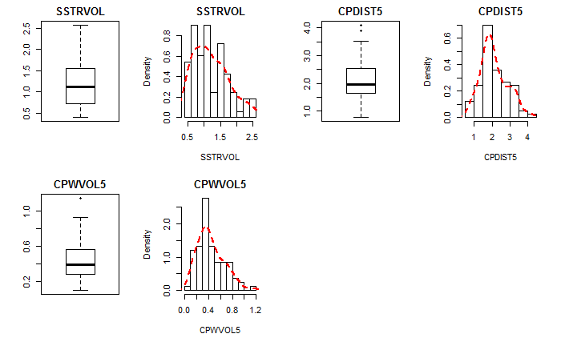

```r
par(mfrow = c(2, 4))
varlist <- names(oj_subset)[2:12]
box_hist_plot<-function(index) {
  boxplot(oj_subset[,index], main=names(oj_subset[index]),pch=16)
  hist(oj_subset[,index],main=names(oj_subset[index]),xlab=names(oj_subset[index]),prob=T)
  lines(density(oj_subset[,index]),lty="dashed",lwd=2.5,col="red")
  }
lapply(2:12,FUN=box_hist_plot)
```

## 16.6 Wealthiest Store and Poorest Store Analysis

```r
##Reference: Data Mining and Business Analytics with R Book by Johannes Ledolter
library(lattice)
par(mfrow = c(1, 2))
t21=tapply(oj$INCOME,oj$store,FUN=mean,na.rm=TRUE)
t21[t21==max(t21)]
```

```
     62
11.2362
```

```r
t21[t21==min(t21)]
```

```
      75
9.867083
```

```r
print(t21[t21==min(t21)])
```

```
      75
9.867083
```

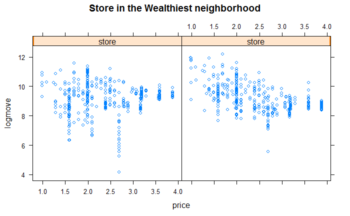

```r
oj1=oj[oj$store == 62,]
oj2=oj[oj$store == 75,]
oj3=rbind(oj1,oj2)
xyplot(logmove~price|store,data=oj3,main="Store in the Wealthiest neighborhood")
```

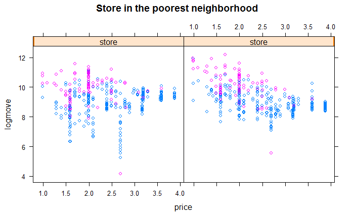

```r
xyplot(logmove~price|store,groups=feat,data=oj3,main="Store in the poorest neighborhood")
```

```r
## store in the wealthiest neighborhood
mhigh=lm(logmove~price,data=oj1)
summary(mhigh)
```

```
Call:
lm(formula = logmove ~ price, data = oj1)

Residuals:
    Min      1Q  Median      3Q     Max
-4.9557 -0.4934  0.1815  0.6557  2.4454

Coefficients:
            Estimate Std. Error t value Pr(>|t|)
(Intercept)  9.15394    0.21112  43.359   <2e-16 ***
price       -0.01461    0.08381  -0.174    0.862
---
Signif. codes:  0 ‘***’ 0.001 ‘**’ 0.01 ‘*’ 0.05 ‘.’ 0.1 ‘ ’ 1

Residual standard error: 1.142 on 349 degrees of freedom
Multiple R-squared:  8.712e-05, Adjusted R-squared:  -0.002778
F-statistic: 0.03041 on 1 and 349 DF,  p-value: 0.8617
```

```r
plot(logmove~price,data=oj1,xlim=c(0,4),ylim=c(0,13),main="62 Wealthiest Store")
abline(mhigh)
```

```r
## store in the poorest neighborhood
mlow=lm(logmove~price,data=oj2)
summary(mlow)
```

```
Call:
lm(formula = logmove ~ price, data = oj2)

Residuals:
    Min      1Q  Median      3Q     Max
-3.5235 -0.5606  0.0392  0.5090  2.4523

Coefficients:
            Estimate Std. Error t value Pr(>|t|)
(Intercept) 10.87695    0.15184   71.63   <2e-16 ***
price       -0.67222    0.06071  -11.07   <2e-16 ***
---
Signif. codes:  0 ‘***’ 0.001 ‘**’ 0.01 ‘*’ 0.05 ‘.’ 0.1 ‘ ’ 1

Residual standard error: 0.8383 on 352 degrees of freedom
Multiple R-squared:  0.2584,    Adjusted R-squared:  0.2563
F-statistic: 122.6 on 1 and 352 DF,  p-value: < 2.2e-16
```

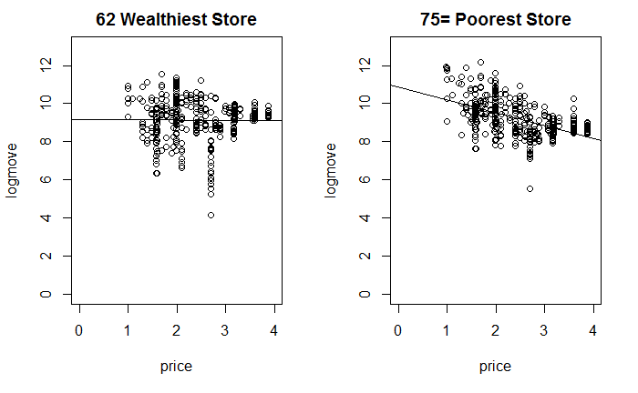

```r
plot(logmove~price,data=oj2,xlim=c(0,4),ylim=c(0,13),main="75= Poorest Store")
abline(mlow)
```

# 17 Linear Regression Models

[Reference UCLA.EDU](http://www.ats.ucla.edu/stat/r/pages/looping_strings.htm)

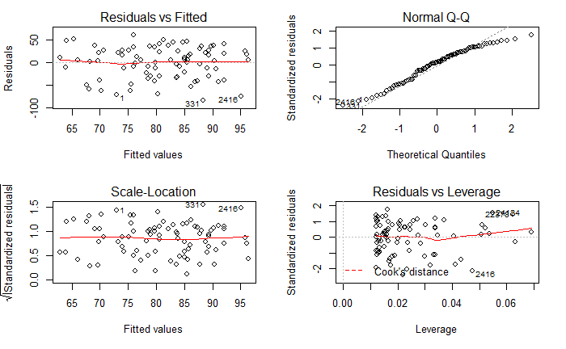

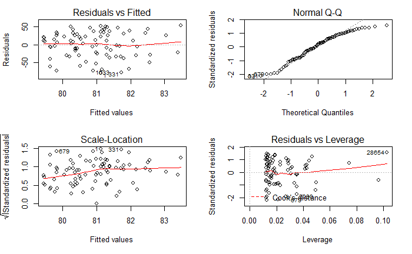

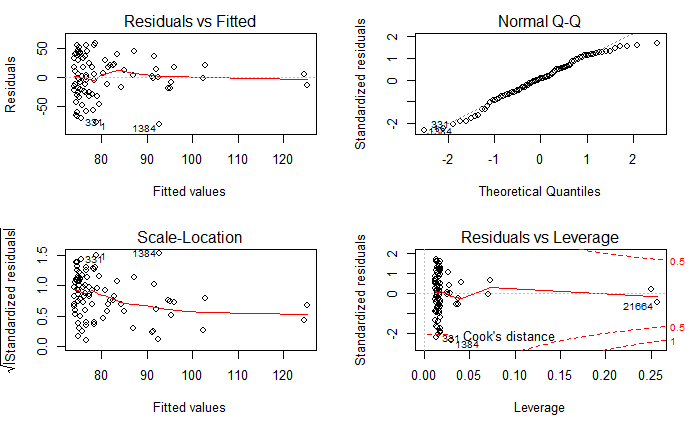

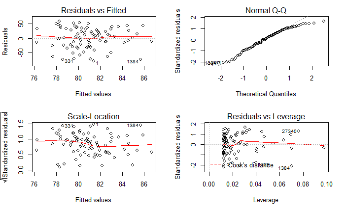

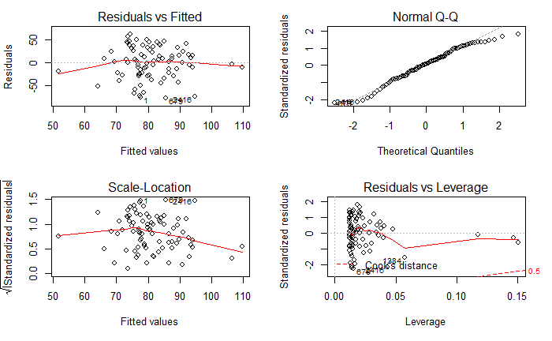

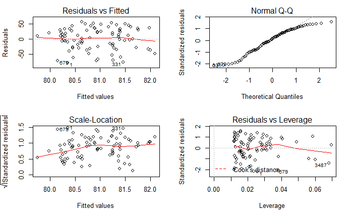

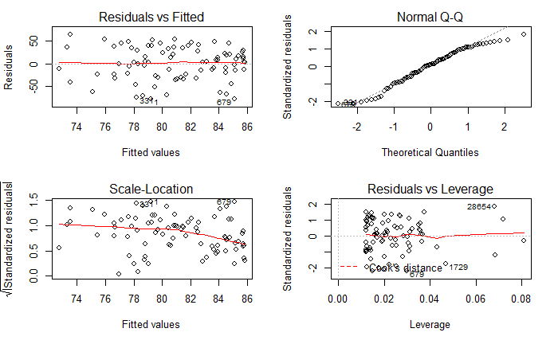

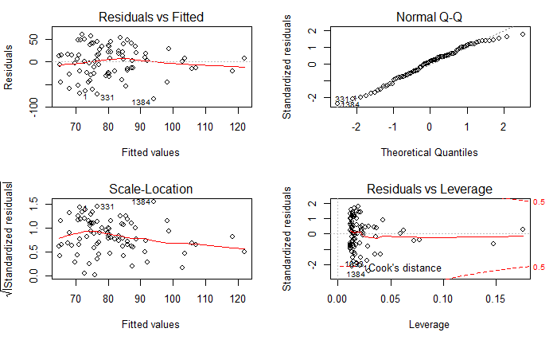

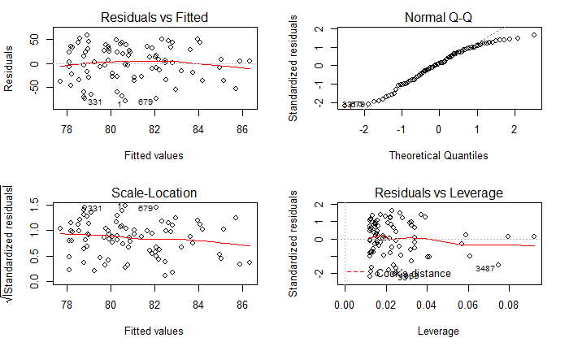

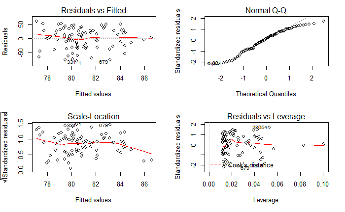

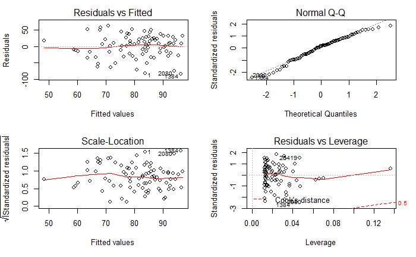

```r
#Reference: http://www.ats.ucla.edu/stat/r/pages/looping_strings.htm
varlist <- names(oj_subset)[2:12]
models <- lapply(varlist, function(x) {
    lm(substitute(store ~ i, list(i = as.name(x))), data = oj_subset)
})
par(mfrow = c(2, 2))
invisible(lapply(models, plot))
```